# Modelling Eyetracking Data

20 April 2018

## From last week

- Last week we looked at the lm() function to run a linear regression
- This can fit a straight line to data
- This line is of the function \(y = mx + c\)
- *m* indicates the slope and *c* indicates the intercept

## From last week

- What about when that isn't appropriate?
- Let me show you an example

## ChickWeights

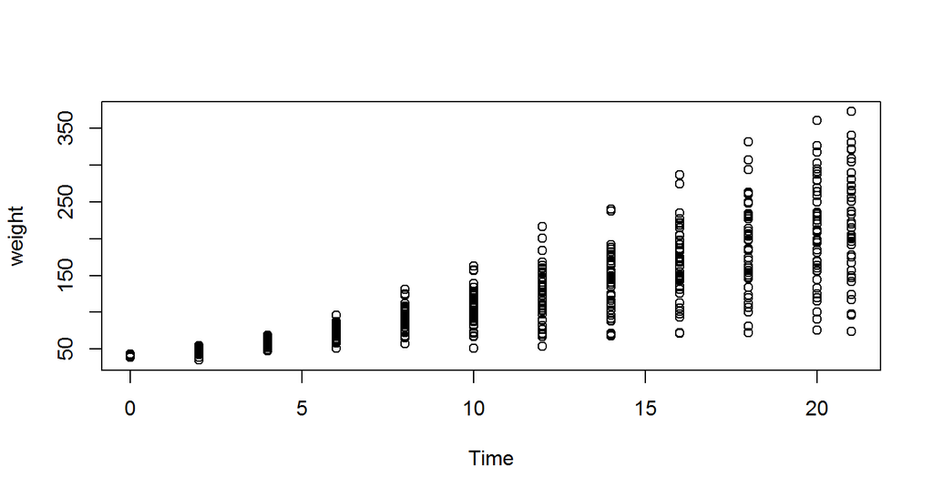

```r
> setwd('~/R_Workshops')
> ChickWeight <- ChickWeight
> plot(weight~Time , data = ChickWeight)
```

## Linear Regression

```r
> chickmod <- lm(weight ~ Time, data = ChickWeight)
>
> ChickWeight$fit <- fitted(chickmod)
>
> lines(ChickWeight$Time, ChickWeight$fit, col = 2)
```

## Linear Regression

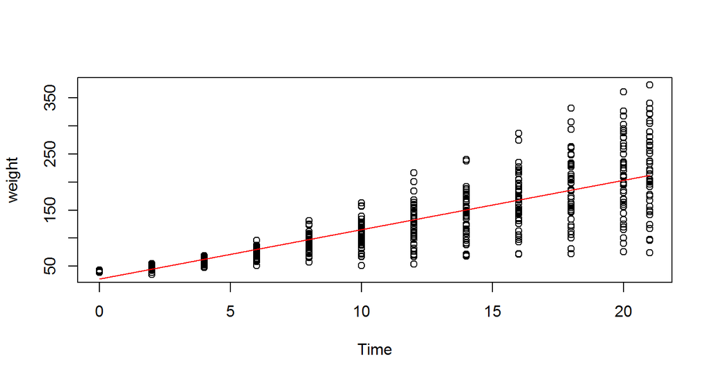

## Test the model

- We test linear regression with a Quantile-Quantile plot of the residuals

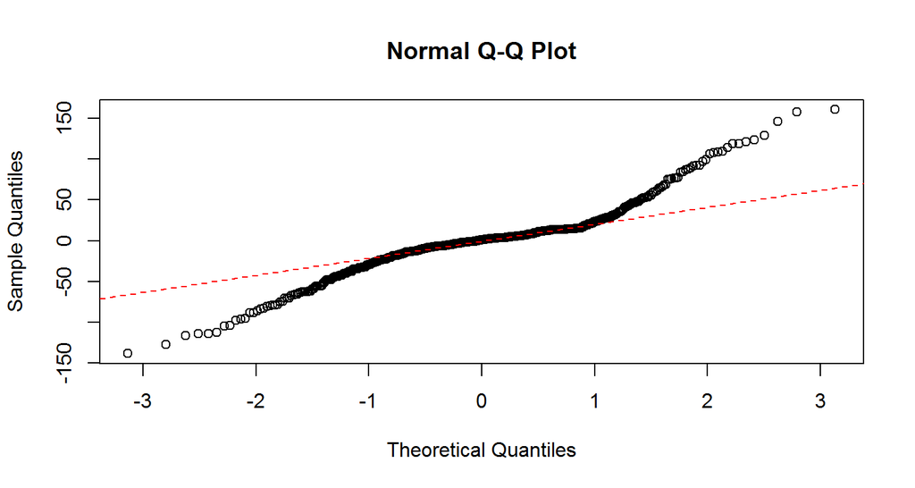

```r
> qqnorm(resid(chickmod))
> qqline(resid(chickmod), col = 2, lty = 2)
```

## Test the model

- A linear regression is inappropriate because it fails to capture the data
- An assumption is that the residuals will be normally distributed
- We can see from our data that this is inappropriate

## A better look at the data

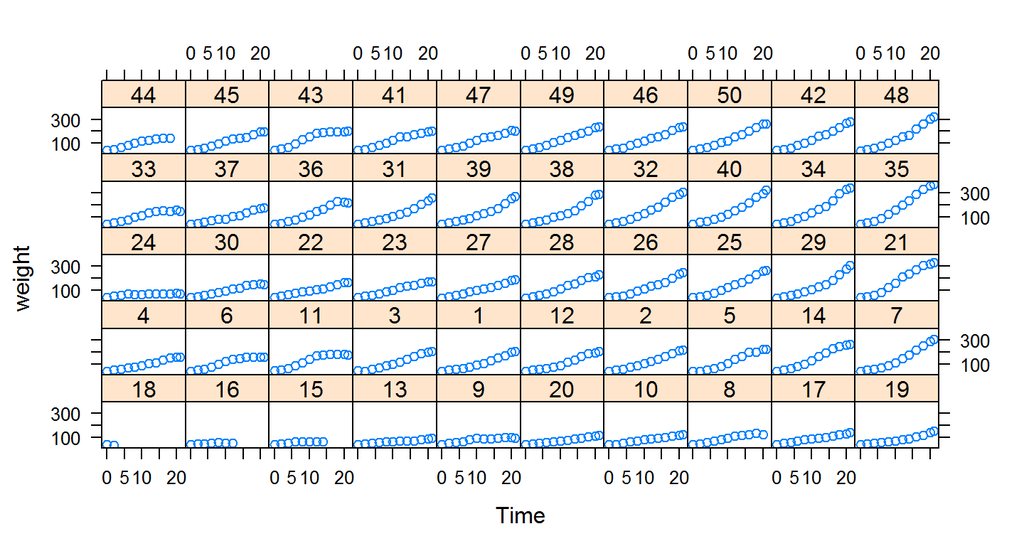

```r
> library(lattice)
> xyplot(weight ~ Time | Chick, data = ChickWeight)
```

## A better look at the data

- We have forgotten two things:
  1. starting weight of each chick might vary (but not a lot in this case)
  2. growth rate of each chick varies dramatically
- We need to take this into account!

## Introducing lmer()

- lmer(), from lme4 allows fitting linear *mixed-effects* regression
- Using this we can take group or individual differences into account
- Remember \(y = mx + c\)?
- Both m and c come with a certain amount of error, which we account for this way

## Introducing lmer

- lm() only allowed us to fit the fixed effects of the model
- lmer() fits random and fixed effects
- Let's try it

## Adding a random intercept

- We do that with + (item|Object)

```r
> library(lme4)
```

```
Loading required package: Matrix
```

```r
> chickmod2 <- lmer(weight ~ Time + (1|Chick), data = ChickWeight)
```

## Adding a random slope

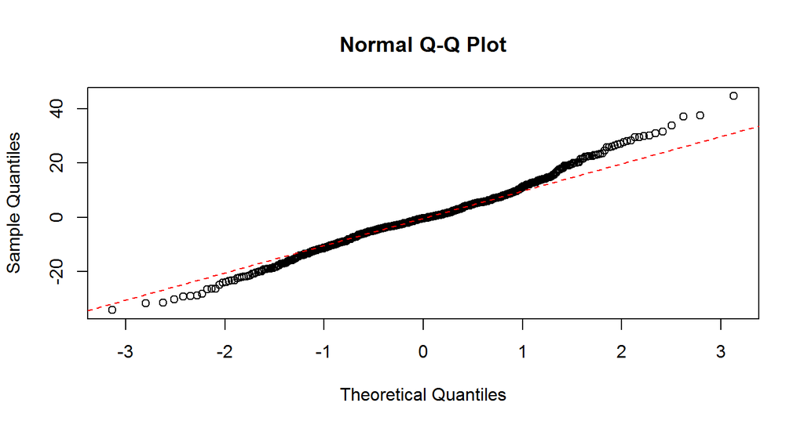

```r
> chickmod3 <- lmer(weight ~ Time + (Time|Chick), data = ChickWeight)
> qqnorm(resid(chickmod3))
> qqline(resid(chickmod3), col = 2, lty = 2)
```

## Compare models

```r
> anova(chickmod2, chickmod3)
```

```
refitting model(s) with ML (instead of REML)
```

```
Data: ChickWeight
Models:
chickmod2: weight ~ Time + (1 | Chick)
chickmod3: weight ~ Time + (Time | Chick)
          Df    AIC    BIC  logLik deviance Chisq Chi Df Pr(>Chisq)
chickmod2  4 5630.3 5647.8 -2811.2   5622.3
chickmod3  6 4841.8 4868.0 -2414.9   4829.8 792.5      2  < 2.2e-16 ***
---
Signif. codes:  0 '***' 0.001 '**' 0.01 '*' 0.05 '.' 0.1 ' ' 1
```

## Assess model

```r
> coef(summary(chickmod3))
```

```
             Estimate Std. Error  t value
(Intercept) 29.177999  1.9572603 14.90757
Time         8.453052  0.5408266 15.62987
```

```r
> ChickWeight$fit2 <- fitted(chickmod3)
```

## View model fit

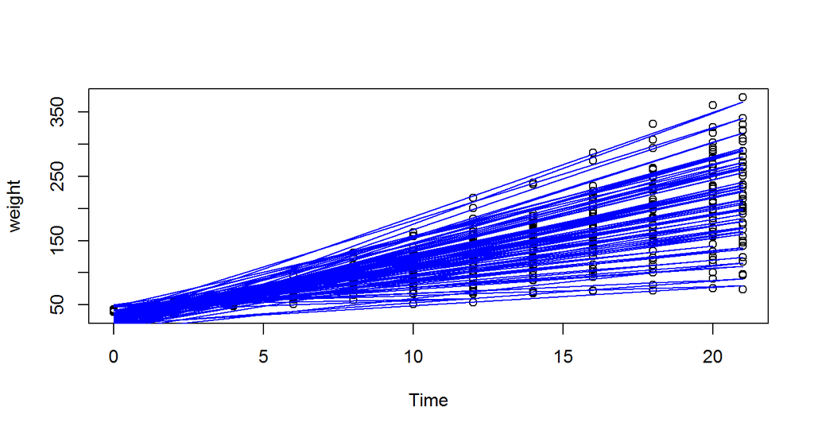

```r
> plot(weight~Time , data = ChickWeight)
> lines(ChickWeight$Time, ChickWeight$fit2, col = 4)
```

## Eyetracking Analysis with eyetrackingR

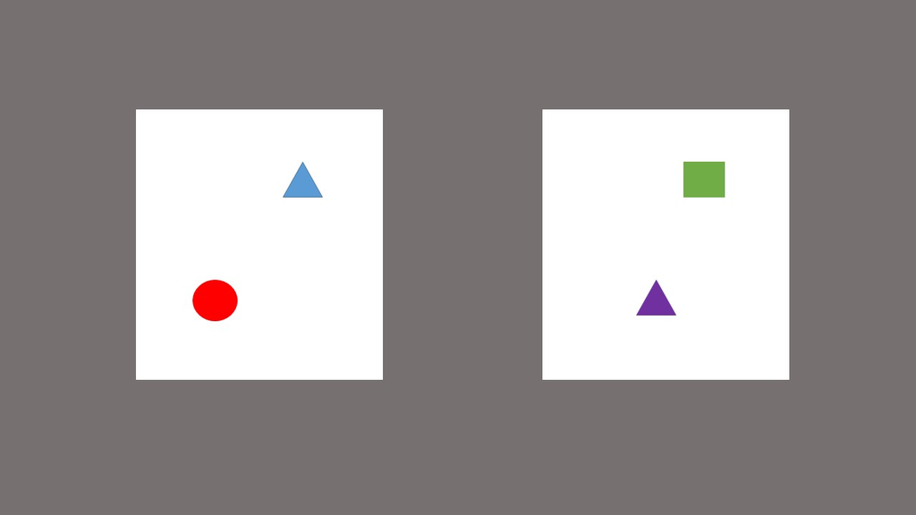

## Eyetracking Analysis with eyetrackingR

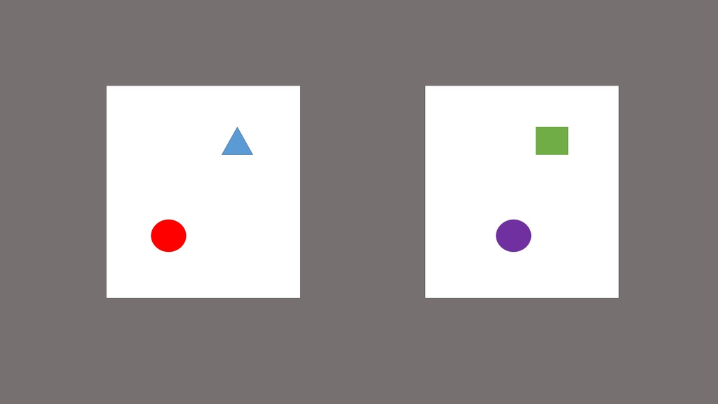

## Eyetracking Analysis with eyetrackingR

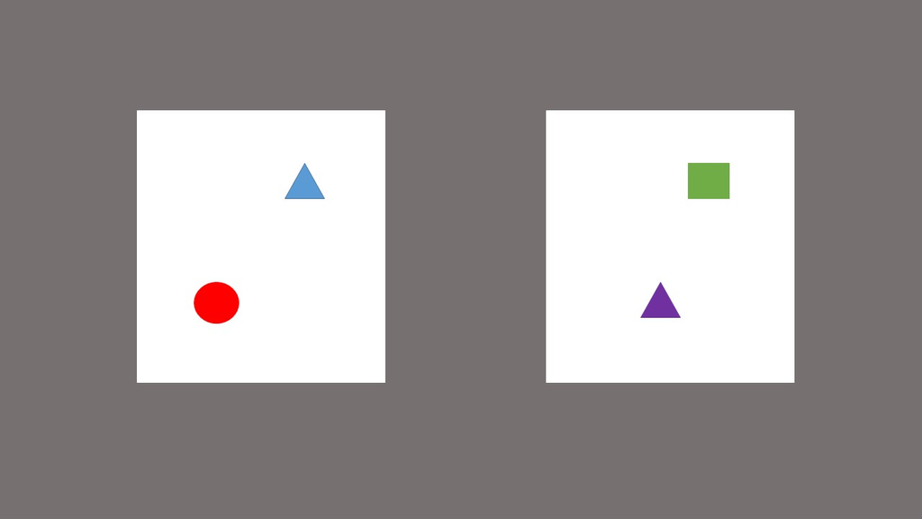

## Eyetracking Analysis with eyetrackingR

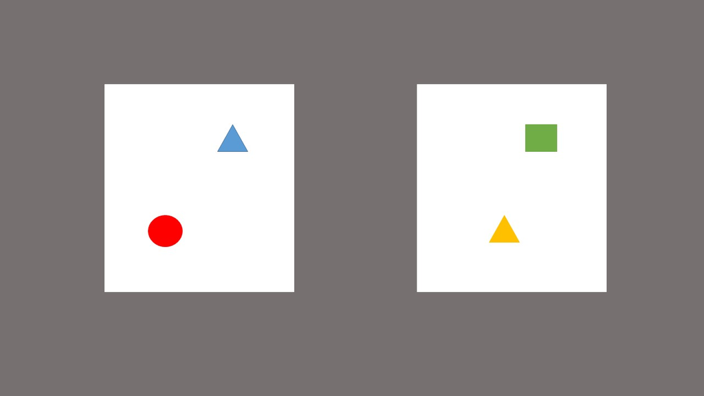

## Load up your data and take a good look

```r
> shape <- read.csv('ShapeBias2.csv')
```

- What are our column types?
- What do we need to change?

## Editing column types

- fix column types

```r
> shape$TrialType <- as.character(shape$TrialType)
> shape$Looking <- as.character(shape$Looking)
> shape$Recording <- as.character(shape$Recording)
> shape$Start_Time <- as.numeric(shape$Start_Time)
```

## Adding target columns

- We can use the *ifelse()* function instead of a for loop
- format is ifelse(condition, what to do if yes, what to do if no)

```r
> shape$Target <- ifelse(shape$Looking == shape$TrialType, 1, 0)
> shape$Other <- ifelse(shape$Looking == 'Out', 1, 0)
> shape$Distractor <- ifelse(shape$Target == 0 & shape$Other == 0, 1, 0)
```

## EyetrackingR

```r
> library(eyetrackingR)
```

```
Loading required package: dplyr
```

```
Attaching package: 'dplyr'
```

```
The following objects are masked from 'package:stats':

    filter, lag
```

```
The following objects are masked from 'package:base':

    intersect, setdiff, setequal, union
```

## EyetrackingR

```r
> data <- make_eyetrackingr_data(
+           data = shape,
+           time_column = 'Timestamp',
+           participant_column = 'Recording',
+           trial_column = 'Trials',
+           aoi_columns = c('Target', 'Distractor'),
+           trackloss_column = 'Other',
+           treat_non_aoi_looks_as_missing = T)
```

```
Converting Participants to proper type.
```

```
Converting Trial to proper type.
```

```
Converting Trackloss to proper type.
```

```
Converting AOI to proper type.
Converting AOI to proper type.
```

## Make a meaningful time column

- EyetrackingR makes nice options for re-leveling the data we want

```r
> response_window <- subset_by_window(data,
+                          window_start_time = 23000,
+                          rezero = T, remove = F)
```

## Analysing trackloss

```r
> #get trackloss data
> trackloss <- trackloss_analysis(data = response_window)
> #clean
> response_window_clean <- clean_by_trackloss(
+                 data = response_window,
+                 trial_prop_thresh = .3,
+                 participant_prop_thresh = .5)
```

```
Performing Trackloss Analysis...
```

```
Will exclude trials whose trackloss proportion is greater than : 0.3
```

```
    ...removed  13  trials.
```

```
Will exclude participants whose trackloss proportion is greater than : 0.5
```

```
    ...removed  0  participants.
```

## Analysing Trackloss

- What are we left with?

```r
> trackloss_clean <- trackloss_analysis(data = response_window_clean)
```

## Basic window analysis

```r
> library(ggplot2)
> theme_set(theme_classic(base_size = 15))
>
> response_window_agg_by_sub <- make_time_window_data(
+   response_window_clean,
+         aois='Target',
+       predictor_columns=c('TrialType'),
+       summarize_by = "Recording")
```

## Basic window analysis

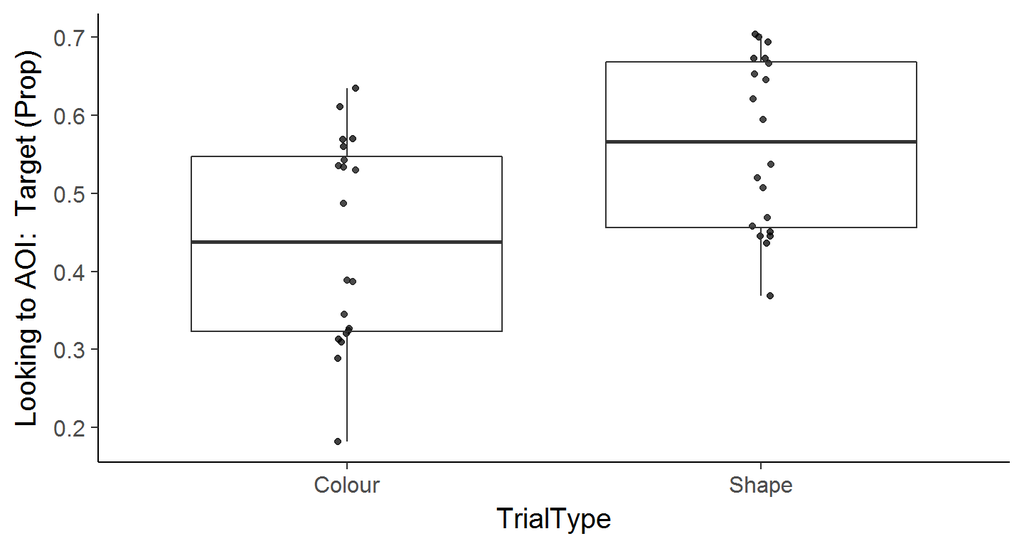

```r
> plot(response_window_agg_by_sub,
+      predictor_columns = 'TrialType', dv = 'Prop')
```

## Basic window analysis

- How is Prop looking?

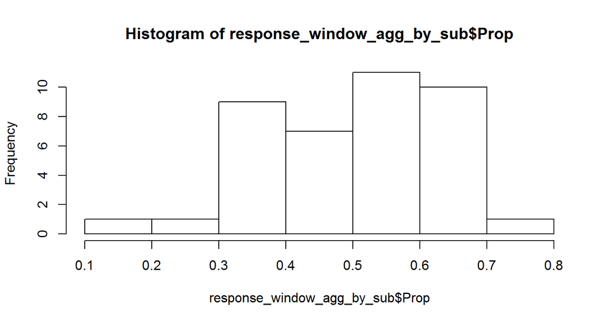

```r
> hist(response_window_agg_by_sub$Prop)
```

## Basic window analysis

```r
> t.test(Prop ~ TrialType,
+        data = response_window_agg_by_sub, paired = T)
```

```
    Paired t-test

data:  Prop by TrialType
t = -2.4427, df = 19, p-value = 0.02452
alternative hypothesis: true difference in means is not equal to 0
95 percent confidence interval:
 -0.23243272 -0.01791828
sample estimates:
mean of the differences
             -0.1251755
```

## GCA

```r
> response_time <- make_time_sequence_data(
+   data = response_window_clean,
+   time_bin_size = 100,
+   aois = 'Target',
+   predictor_columns = 'TrialType')
```

## GCA

- Take a look at the data
- ot1, ot2 etc refer to *Orthogonal Polynomials*
- Like with the window analysis, we have multiple DV options

## Let's peek

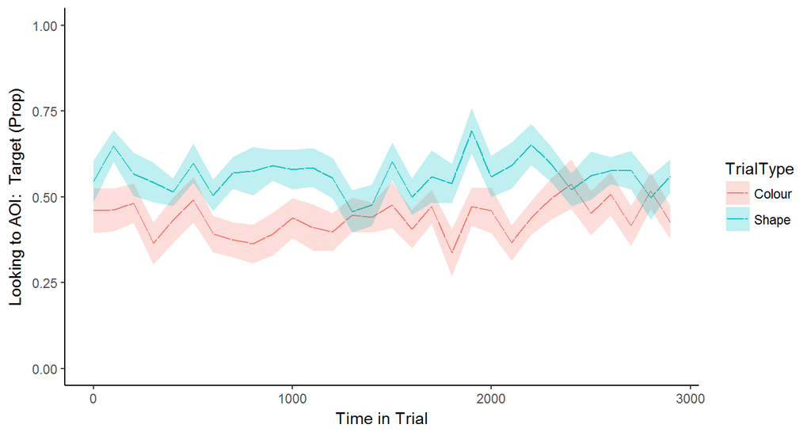

```r
> plot(response_time, predictor_column = "TrialType") +
+   theme_classic() +
+   coord_cartesian(ylim = c(0,1))
```

## So what is our DV?

- Something almost this extreme is not uncommon for babies

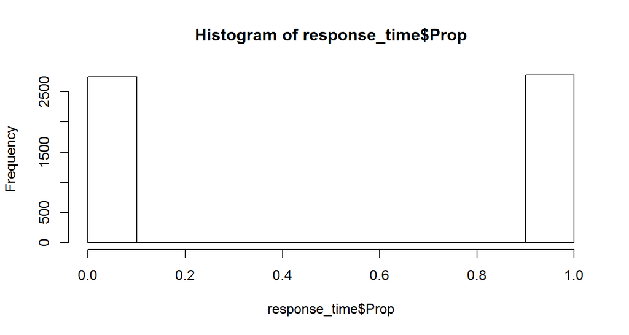

```r
> hist(response_time$Prop)
```

## Fit a linear model (just linear time)

```r
> l.m <- lmer(Elog ~ ot1 * TrialType +
+               (1|Recording) + (1|Trials),
+              REML = F, data = response_time)
```

## And check the fit

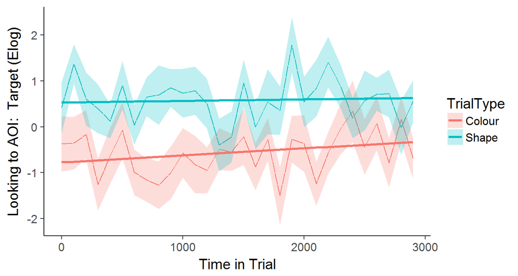

```r
> plot(response_time,
+      predictor_column = "TrialType",
+      dv = 'Elog', model = l.m)
```

## Polynomials

- If the data is not linear, we may need extra terms
- We can use polynomials to better fit the data

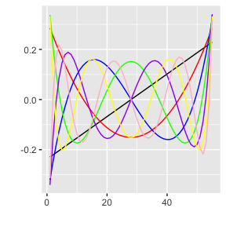

## So you think you need a polynomial

```r
> plot(response_time, predictor_column = "TrialType" ) +
+   stat_smooth() +
+   theme_classic() +
+   coord_cartesian(ylim = c(0,1))
```

```
`geom_smooth()` using method = 'loess'
```

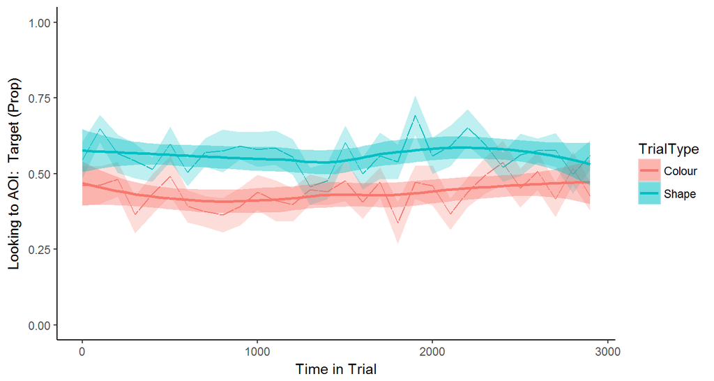

## Cubic polynomial

```r
> l2.m <- lmer(Elog ~ (ot1 + ot2 + ot3) * TrialType +
+               (1|Recording) + (1|Trials),
+             REML = F, data = response_time)
```

## Cubic model

- Check the output

```r
> summary(l2.m)
```

```
Linear mixed model fit by maximum likelihood  ['lmerMod']
Formula: Elog ~ (ot1 + ot2 + ot3) * TrialType + (1 | Recording) + (1 |
    Trials)
   Data: response_time

     AIC      BIC   logLik deviance df.resid
 32465.8  32538.6 -16221.9  32443.8     5507

Scaled residuals:
    Min      1Q  Median      3Q     Max
-1.2454 -0.9599  0.7922  0.9293  1.2528

Random effects:
 Groups    Name        Variance Std.Dev.
 Recording (Intercept)  0.03911 0.1978
 Trials    (Intercept)  0.01447 0.1203
 Residual              20.89815 4.5714
Number of obs: 5518, groups:  Recording, 20; Trials, 12

Fixed effects:
                   Estimate Std. Error t value
(Intercept)        -0.55127    0.10986  -5.018
ot1                 0.72204    0.48151   1.500
ot2                 0.84495    0.47968   1.761
ot3                -0.58317    0.48092  -1.213
TrialTypeShape      1.12797    0.14149   7.972
ot1:TrialTypeShape -0.56774    0.67546  -0.841
ot2:TrialTypeShape -0.82782    0.67546  -1.226
ot3:TrialTypeShape -0.06317    0.67505  -0.094

Correlation of Fixed Effects:
            (Intr) ot1    ot2    ot3    TrlTyS o1:TTS o2:TTS
ot1         -0.006
ot2          0.006 -0.002
ot3          0.004  0.002 -0.008
TrialTypShp -0.650  0.004 -0.005 -0.003
ot1:TrlTypS  0.004 -0.713  0.001 -0.001 -0.008
ot2:TrlTypS -0.004  0.001 -0.710  0.005  0.003 -0.006
ot3:TrlTypS -0.003 -0.001  0.005 -0.712  0.002  0.004 -0.014
```

## Check the fit

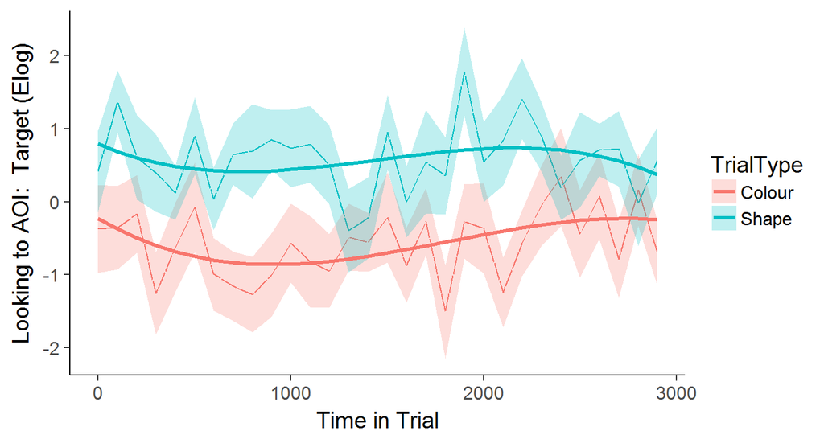

```r
> plot(response_time, predictor_column = "TrialType",
+      dv = 'Elog', model = l2.m)
```

## Check the assumptions

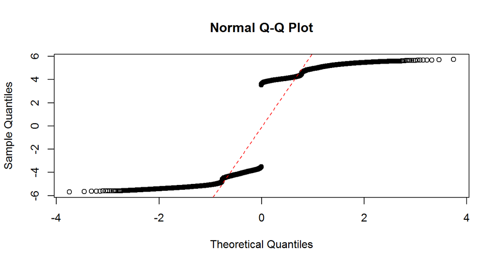

```r
> qqnorm(resid(l2.m))
> qqline(resid(l2.m), col = 2, lty = 2)
```

## Can we do better???

```r
> full.m <- lmer(Elog ~ (ot1 + ot2 + ot3) * TrialType +
+                  (ot1 |Recording) +
+                  (ot1 |Trials),
+                REML = F, data = response_time)
```

## Check the difference

```r
> anova(full.m, l2.m)
```

```
Data: response_time
Models:
l2.m: Elog ~ (ot1 + ot2 + ot3) * TrialType + (1 | Recording) + (1 |
l2.m:     Trials)
full.m: Elog ~ (ot1 + ot2 + ot3) * TrialType + (ot1 | Recording) + (ot1 |
full.m:     Trials)
       Df   AIC   BIC logLik deviance  Chisq Chi Df Pr(>Chisq)
l2.m   11 32466 32539 -16222    32444
full.m 15 32474 32573 -16222    32444 0.0115      4          1
```

## A fully specified model

- All our time terms should be nested for this to make sense
- But there is considerable debate about this
- Because our data is transformed, the residuals make little sense
- I always advise caution here, because it's hard to check our working
- This is a fast way to approximate it though